# Session 2 Exercises (with answers)

Ben Raymond, Adrien Ickowicz

# Preparation

Load some packages:

```r
library(tidyverse)
library(datavolley)
library(ovlytics)
```

Read in our data

```r
f <- dir("example_data/DE Men 2019", full.names = TRUE, pattern = "\\.dvw$")
x <- lapply(f, dv_read, skill_evaluation_decode = "german")

## concatentate the play-by-play data into one big data frame
px <- bind_rows(lapply(x, plays))
```

Check for inconsistent team names / IDs:

```r
px %>% count(team, team_id) %>% arrange(team)
```

```
##                               team team_id    n
## 1                           BERLIN     BRV  869
## 2         BERLIN RECYCLING Volleys    5413  547
## 3           HELIOS GRIZZLYS Giesen    5432 1302
## 4  HYPO TIROL AlpenVolleys Haching    5570 1567
## 5  Netzhoppers SolWo Königspark KW    5427  844
## 6                     SVG Lüneburg    5430 1443
## 7           SWD powervolleys Düren    5415  837
## 8                    TV Rottenburg    5420 1088
## 9         United Volleys Frankfurt    5444 1251
## 10             VfB Friedrichshafen    5422 1096
## 11          Volleyball Bisons Bühl    5419 1428
## 12          WWK Volleys Herrsching    5448 1652
## 13                            <NA>    <NA>  110
```

```r
x <- remap_team_names(x, remap = tibble(from = "BERLIN", to = "BERLIN RECYCLING Volleys", to_team_id = "5413"))

px <- bind_rows(lapply(x, plays))
px %>% count(team, team_id) %>% arrange(team)
```

```
##                               team team_id    n
## 1         BERLIN RECYCLING Volleys    5413 1416
## 2           HELIOS GRIZZLYS Giesen    5432 1302
## 3  HYPO TIROL AlpenVolleys Haching    5570 1567
## 4  Netzhoppers SolWo Königspark KW    5427  844
## 5                     SVG Lüneburg    5430 1443
## 6           SWD powervolleys Düren    5415  837
## 7                    TV Rottenburg    5420 1088
## 8         United Volleys Frankfurt    5444 1251
## 9              VfB Friedrichshafen    5422 1096
## 10          Volleyball Bisons Bühl    5419 1428
## 11          WWK Volleys Herrsching    5448 1652
## 12                            <NA>    <NA>  110
```

```r
check_player_names(x)
```

```
##                      team1 team_id1          player1 player_id1 count1
## 1 United Volleys Frankfurt     5444 Moritz Karlitzek       6510      2
##                      team2 team_id2          player2 player_id2 count2
## 1 United Volleys Frankfurt     5444 Lorenz Karlitzek       7213      2
```

Add some extra columns:

```r
px <- ov_augment_plays(px, to_add = "all")
```

# Exercises

### 1. What is the mean serve error rate?

**Click for solution**

```r
px %>% filter(skill == "Serve") %>%
    summarize(error_rate = mean(evaluation == "Error"))
```

```
##   error_rate
## 1  0.1501211
```

### 2. By team?

**Click for solution**

```r
px %>% filter(skill == "Serve") %>%
    group_by(team) %>%
    summarize(error_rate = mean(evaluation == "Error"))
```

```
## # A tibble: 11 × 2
##    team                            error_rate
##    <chr>                                <dbl>
##  1 BERLIN RECYCLING Volleys             0.143
##  2 HELIOS GRIZZLYS Giesen               0.154
##  3 HYPO TIROL AlpenVolleys Haching      0.176
##  4 Netzhoppers SolWo Königspark KW      0.179
##  5 SVG Lüneburg                         0.170
##  6 SWD powervolleys Düren               0.15
##  7 TV Rottenburg                        0.175
##  8 United Volleys Frankfurt             0.124
##  9 VfB Friedrichshafen                  0.109
## 10 Volleyball Bisons Bühl               0.138
## # … with 1 more row
```

### 3. By team, but only for Herrsching and Giesen? (First find their full team names in the data set)

**Click for solution**

```r
px %>% filter(skill == "Serve") %>%
    filter(team %in% c("HELIOS GRIZZLYS Giesen", "WWK Volleys Herrsching")) %>%
    group_by(team) %>%
    summarize(error_rate = mean(evaluation == "Error"))
```

```
## # A tibble: 2 × 2
##   team                   error_rate
##   <chr>                       <dbl>
## 1 HELIOS GRIZZLYS Giesen      0.154
## 2 WWK Volleys Herrsching      0.144
```

### 4. By player?

**Click for solution**

```r
px %>% filter(skill == "Serve") %>%
    group_by(player_name) %>%
    summarize(error_rate = mean(evaluation == "Error"))
```

```
## # A tibble: 103 × 2
##    player_name          error_rate
##    <chr>                     <dbl>
##  1 Adam Kocian              0.172
##  2 Adam Schriemer           0.0870
##  3 Adam White               0.114
##  4 Akhrorjon Sobirov        0.217
##  5 Alex Duncan-Thibault     0.111
##  6 Alpár József Szabó       0.108
##  7 André Illmer             0.333
##  8 Andreas Takvam           0.0625
##  9 Anton Qafarena           0
## 10 Antwain Aguillard        0.312
## # … with 93 more rows
```

Followup: would it be helpful to `group_by(player_name, player_id)` or `group_by(player_name, team)` ?

### 5. Produce a table (data frame) of mean serve error rate and mean ace rate by team

**Click for solution**

```r
team_errors_aces <- px %>% filter(skill == "Serve") %>%
    group_by(team) %>%
    summarize(error_rate = mean(evaluation == "Error"), ace_rate = mean(evaluation == "Ace"))

team_errors_aces
```

```
## # A tibble: 11 × 3
##    team                            error_rate ace_rate
##    <chr>                                <dbl>    <dbl>
##  1 BERLIN RECYCLING Volleys             0.143   0.0595
##  2 HELIOS GRIZZLYS Giesen               0.154   0.0336
##  3 HYPO TIROL AlpenVolleys Haching      0.176   0.106
##  4 Netzhoppers SolWo Königspark KW      0.179   0.0632
##  5 SVG Lüneburg                         0.170   0.0682
##  6 SWD powervolleys Düren               0.15    0.03
##  7 TV Rottenburg                        0.175   0
##  8 United Volleys Frankfurt             0.124   0.0435
##  9 VfB Friedrichshafen                  0.109   0.0816
## 10 Volleyball Bisons Bühl               0.138   0.0314
## # … with 1 more row
```

### 6. Use that to plot mean serve error rate vs mean ace rate

**Click for solution**

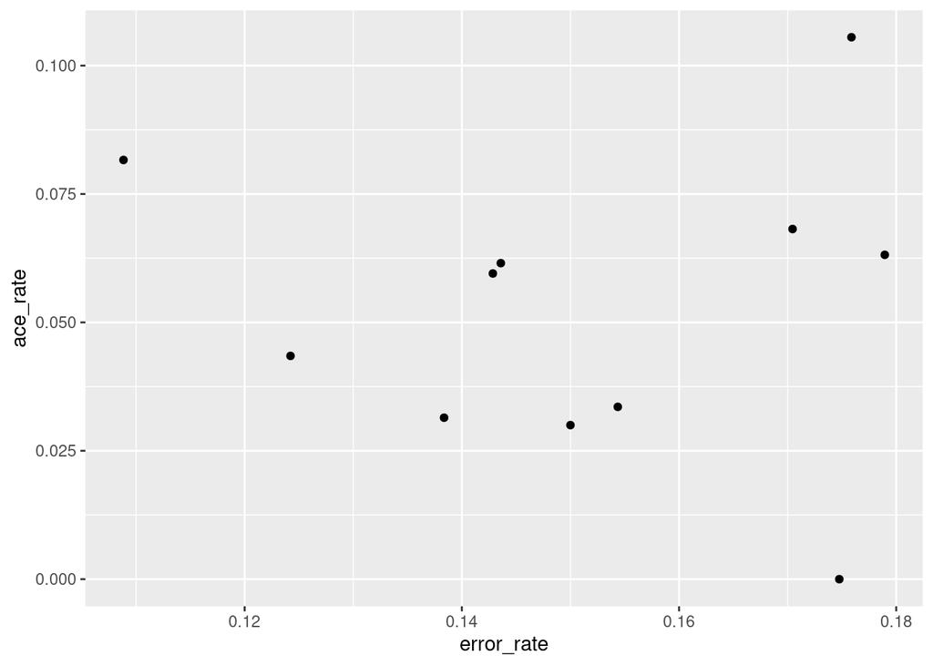

```r
ggplot(team_errors_aces, aes(error_rate, ace_rate)) + geom_point()
```

### 7. What is the average sideout rate by pass quality (i.e. sideout rate on perfect passes, sideout rate on good passes, etc)

**Click for solution**

```r
px %>% filter(skill == "Reception") %>%
    group_by(evaluation) %>%
    summarize(sideout_rate = mean(point_won_by == team))
```

```
## # A tibble: 6 × 2
##   evaluation                  sideout_rate
##   <chr>                              <dbl>
## 1 Error                              0
## 2 Negative, limited attack           0.553
## 3 OK, no first tempo possible        0.645
## 4 Perfect pass                       0.774
## 5 Poor, no attack                    0.307
## 6 Positive, attack                   0.738
```

### 8. Calculate the first-ball attack kill rate (i.e. kill rate on attacks made on serve reception)

**Click for solution**

```r
px %>% filter(skill == "Attack" & phase == "Reception") %>%
    group_by(team) %>%
    summarize(first_ball_kill_rate = mean(evaluation == "Winning attack"))
```

```
## # A tibble: 11 × 2
##    team                            first_ball_kill_rate
##    <chr>                                          <dbl>
##  1 BERLIN RECYCLING Volleys                       0.560
##  2 HELIOS GRIZZLYS Giesen                         0.484
##  3 HYPO TIROL AlpenVolleys Haching                0.566
##  4 Netzhoppers SolWo Königspark KW                0.442
##  5 SVG Lüneburg                                   0.564
##  6 SWD powervolleys Düren                         0.472
##  7 TV Rottenburg                                  0.450
##  8 United Volleys Frankfurt                       0.534
##  9 VfB Friedrichshafen                            0.632
## 10 Volleyball Bisons Bühl                         0.508
## # … with 1 more row
```

### 9. Calculate the breakpoint rate (fraction of points won while serving) by rotation (use the `setter_position` column), for all teams combined

**Click for solution**

```r
px %>% filter(skill == "Serve") %>%
    group_by(setter_position) %>%
    summarize(breakpoint_rate = mean(point_won_by == team))
```

```
## # A tibble: 6 × 2
##   setter_position breakpoint_rate
##             <int>           <dbl>
## 1               1           0.372
## 2               2           0.313
## 3               3           0.314
## 4               4           0.311
## 5               5           0.338
## 6               6           0.326
```